# Identification of Aneuploid Chromosomes

Author

Claudia Zirión-Martínez

Published

May 19, 2025

## Setup

Libraries

```r
library(tidyverse)
library(RColorBrewer)
library(svglite)
```

Paths

Use the metadata table generated by `analyses/scripts/metadata.ipynb`  
and the `cnv_chromosomes.tsv` of the joined dataset generated by WeavePop.

```r
# Input
metadata_path <-
    "../Crypto_Desjardins_Ashton/results/02.Dataset/metadata.csv"
chromosomes_path <-
    "../Crypto_Desjardins_Ashton/results/02.Dataset/chromosomes.csv"
cnv_chroms_path <-
    "../Crypto_Desjardins_Ashton/results/02.Dataset/cnv/cnv_chromosomes.tsv"

# Output
chrom_metrics_path <- "results/tables/chromosome_cnv_categories.tsv"

barplot_aneup_category_dups_path1 <- "results/figures/barplot_aneuploidy_category.svg"
barplot_size_category_dups_path <- "results/figures_extra/barplot_size_category.svg"
```

## Prepare dataset

### Metadata

Use the metadata table that has all the samples included in the final **Crypto_Desjardins_Ashton** dataset (n = 1016).  
Select needed columns, get the number of samples per dataset and lineage, per lineage, per lineage and source and total.

```r
metadata <- read.delim(
    metadata_path,
    header=TRUE,
    sep=",",
    stringsAsFactor = TRUE)
metadata <- metadata %>%
    select(sample, strain, source, lineage, dataset, sublineage)%>%
    group_by(dataset, lineage)%>%
    mutate(samples_in_dataset_lineage = n_distinct(sample))%>%
    ungroup() %>%
    group_by(lineage)%>%
    mutate(samples_in_lineage = n_distinct(sample))%>%
    ungroup() %>%
    group_by(sublineage)%>%
    mutate(samples_in_sublineage = n_distinct(sample))%>%
    ungroup() %>%
    group_by(lineage,source,samples_in_lineage) %>%
    mutate(samples_in_lineage_source = n_distinct(sample))%>%
    ungroup()%>%
    mutate(total_samples = n_distinct(sample))%>%
    droplevels()

metadata_lin_source <- metadata %>%
    select(lineage, source, samples_in_lineage, samples_in_lineage_source, total_samples)%>%
    distinct()
```

```r
n_lineage <- metadata %>%
    select(lineage, samples_in_lineage)%>%
    distinct()
```

## CNV metrics per chromosome

Read the table with the information of each type of CNV in each chromosome of all samples.  
Remove single-copy rows.

```r
chromosomes <- read.delim(
    chromosomes_path,
    header=TRUE,
    sep=",",
    stringsAsFactor = TRUE)%>%
    rename(lineage = "ref_genome")

cnv_chroms <- read.delim(
    cnv_chroms_path,
    header = TRUE,
    sep = "\t")%>%
    left_join(chromosomes, by = "accession")%>%
    filter(cnv != "single_copy")

cnv_chroms$chromosome <- as.factor(cnv_chroms$chromosome)

cnv_chroms$lineage <- factor(cnv_chroms$lineage, levels = c("VNI", "VNBI", "VNBII", "VNII"))
```

## Categorize by percent of coverage

### Three categories by “aneuploidy”

Use thresholds to make categories according to the percentage of the size of the chormosome covered by CNVs.

- full: [full_threshold, 100]
- partial: (euploid_threshold, full_threshold)
- euploid: [0, euploid_threshold]

```r
euploid_threshold <- 20
full_threshold <- 80
```

```r
chrom_metrics <- cnv_chroms %>%
    mutate(chrom_category_aneuploidy = case_when(
        coverage_percent >= full_threshold ~ "Full",
        coverage_percent > euploid_threshold & coverage_percent < full_threshold ~ "Partial",
        coverage_percent <= euploid_threshold ~ "Euploid",
))
chrom_metrics$chrom_category_aneuploidy <- factor(chrom_metrics$chrom_category_aneuploidy,
                                levels = c("Full", "Partial", "Euploid"))
```

### Four categories by “size”

Use thresholds to make categories according to the percentage of the size of the chormosome covered by CNVs.

- large: [large_threshold, 100]
- medium: (small_threshold, large_threshold)
- small: (absent_threshold, small_threshold]
- absent: [0, absent_threshold]

```r
absent_threshold <- 5
small_threshold <- 20
large_threshold <- 80
```

```r
chrom_metrics <- chrom_metrics %>%
    mutate(chrom_category_size = case_when(
        coverage_percent >= large_threshold ~ "Large",
        coverage_percent > small_threshold & coverage_percent < large_threshold ~ "Medium",
        coverage_percent > absent_threshold & coverage_percent <= small_threshold ~ "Small",
        coverage_percent <= absent_threshold ~ "Absent",
))
chrom_metrics$chrom_category_size <- factor(chrom_metrics$chrom_category_size,
                                levels = c("Large", "Medium", "Small", "Absent"))
```

## Sample metrics

```r
sample_metrics <- chrom_metrics %>%
    group_by(sample, lineage, cnv)%>%
    summarize(category_size = ifelse(any(chrom_category_size == "Large"), "Large",
                                        ifelse(any(chrom_category_size == "Medium"), "Medium",
                                            ifelse(any(chrom_category_size == "Small"), "Small", "Absent"))),
             category_aneuploidy = ifelse(any(chrom_category_aneuploidy == "Full"), "Full",
                                            ifelse(any(chrom_category_aneuploidy == "Partial"), "Partial", "Euploid")))%>%
    left_join(metadata, by = c("sample", "lineage"))%>%
    mutate(source_size = paste(source, category_size),
            source_aneuploidy = paste(source, category_aneuploidy))

sample_metrics$category_size <- factor(sample_metrics$category_size,
                                levels = levels(chrom_metrics$chrom_category_size))

sample_metrics$category_aneuploidy <- factor(sample_metrics$category_aneuploidy,
                                levels = levels(chrom_metrics$chrom_category_aneuploidy))

sample_metrics$source_size <- factor(sample_metrics$source_size, levels = c(
    "Environmental Absent", "Environmental Small" , "Environmental Medium", "Environmental Large",
    "Clinical Absent", "Clinical Small", "Clinical Medium",  "Clinical Large"))

sample_metrics$source_aneuploidy <- factor(sample_metrics$source_aneuploidy, levels = c(
      "Environmental Euploid","Environmental Partial","Environmental Full",
       "Clinical Euploid",  "Clinical Partial", "Clinical Full"
    ))
```

```r
source_aneuploidy_colors <- brewer.pal(11, "BrBG")[c(11,8,7,1,2,5)]
names(source_aneuploidy_colors) <- rev(levels(sample_metrics$source_aneuploidy))
source_size_colors <- brewer.pal(11, "BrBG")[c(11,10,8,7,1,2,4,5)]
names(source_size_colors) <- rev(levels(sample_metrics$source_size))
```

## Join chromosome metrics with metadata and save table

```r
chrom_metrics <- left_join(chrom_metrics, metadata)
```

```r
write.table(chrom_metrics, file = chrom_metrics_path, sep = "\t",  quote = FALSE, row.names = FALSE)
```

## Summaries of samples in each category

### Create function to make summaries

```r
get_summary <- function(df, variable1, variable2=NULL, variable3=NULL, cnv_type, total_n){
    if(is.null(variable2) & is.null(variable3)){
        if(!is.null(cnv_type)){
            df %>%
                filter(cnv == cnv_type) %>%
                group_by(.data[[variable1]],
                .data[[total_n]],)%>%
                summarize(n = n_distinct(sample))%>%
                mutate(percent = (n / .data[[total_n]])*100)%>%
                arrange(.data[[variable1]])
        } else{
            df %>%
                group_by(.data[[variable1]],
                        .data[[variable2]],
                        .data[[total_n]],)%>%
                summarize(n = n_distinct(sample))%>%
                mutate(percent = (n / .data[[total_n]])*100)%>%
                arrange(.data[[variable1]])
        }
    }else if(!is.null(variable2) & is.null(variable3)){
            if(!is.null(cnv_type)){
                df %>%
                    filter(cnv == cnv_type) %>%
                    group_by(.data[[variable1]],
                            .data[[variable2]],
                            .data[[total_n]],)%>%
                    summarize(n = n_distinct(sample))%>%
                    mutate(percent = (n / .data[[total_n]])*100)%>%
                    arrange(.data[[variable1]],
                            .data[[variable2]])
            } else{
                df %>%
                    group_by(.data[[variable1]],
                            .data[[variable2]],
                            .data[[total_n]],)%>%
                    summarize(n = n_distinct(sample))%>%
                    mutate(percent = (n / .data[[total_n]])*100)%>%
                    arrange(.data[[variable1]],
                            .data[[variable2]])
            }
    }else{
            if(!is.null(cnv_type)){
                df %>%
                    filter(cnv == cnv_type) %>%
                    group_by(.data[[variable1]],
                            .data[[variable2]],
                            .data[[variable3]],
                            .data[[total_n]],)%>%
                    summarize(n = n_distinct(sample))%>%
                    mutate(percent = (n / .data[[total_n]])*100)%>%
                    arrange(.data[[variable1]],
                            .data[[variable2]],
                            .data[[variable3]])
            } else{
                df %>%
                    group_by(.data[[variable1]],
                            .data[[variable2]],
                            .data[[variable3]],
                            .data[[total_n]],)%>%
                    summarize(n = n_distinct(sample))%>%
                    mutate(percent = (n / .data[[total_n]])*100)%>%
                    arrange(.data[[variable1]],
                            .data[[variable2]],
                            .data[[variable3]])
            }
    }
}
```

## Summaries of duplications by “aneuploidy” category

**Number of samples with duplications per category**

```r
per_category <- get_summary(df = sample_metrics,
            variable1= "category_aneuploidy",
            cnv_type= "duplication",
            total_n = "total_samples")

per_category
```

| category_aneuploidy | total_samples | n | percent |
| --- | --- | --- | --- |
| Full | 1016 | 36 | 3.543307 |
| Partial | 1016 | 25 | 2.460630 |
| Euploid | 1016 | 955 | 93.996063 |

```r
per_category %>%
    filter(category_aneuploidy != "Euploid")%>%
    group_by(total_samples)%>%
    reframe(n = sum(n),
            percent = n / total_samples*100 )%>%
    distinct()
```

| total_samples | n | percent |
| --- | --- | --- |
| 1016 | 61 | 6.003937 |

**Number of samples with duplications per lineage**

```r
get_summary(df = sample_metrics,
            variable1= "category_aneuploidy",
            variable2= "lineage",
            cnv_type= "duplication",
            total_n = "samples_in_lineage")
```

| category_aneuploidy | lineage | samples_in_lineage | n | percent |
| --- | --- | --- | --- | --- |
| Full | VNI | 818 | 29 | 3.545232 |
| Full | VNBI | 120 | 2 | 1.666667 |
| Full | VNBII | 62 | 2 | 3.225807 |
| Full | VNII | 16 | 3 | 18.750000 |
| Partial | VNI | 818 | 21 | 2.567237 |
| Partial | VNBI | 120 | 2 | 1.666667 |
| Partial | VNBII | 62 | 2 | 3.225807 |
| Euploid | VNI | 818 | 768 | 93.887531 |
| Euploid | VNBI | 120 | 116 | 96.666667 |
| Euploid | VNBII | 62 | 58 | 93.548387 |
| Euploid | VNII | 16 | 13 | 81.250000 |

**Number of samples with duplications in each group of lineage-source**

```r
dup_lin_source <- get_summary(df = sample_metrics,
            variable1= "source_aneuploidy",
            variable2= "lineage",
            cnv_type= "duplication",
            total_n = "samples_in_lineage")
dup_lin_source
```

| source_aneuploidy | lineage | samples_in_lineage | n | percent |
| --- | --- | --- | --- | --- |
| Environmental Euploid | VNI | 818 | 28 | 3.422983 |
| Environmental Euploid | VNBI | 120 | 71 | 59.166667 |
| Environmental Euploid | VNBII | 62 | 3 | 4.838710 |
| Environmental Euploid | VNII | 16 | 1 | 6.250000 |
| Clinical Euploid | VNI | 818 | 740 | 90.464548 |
| Clinical Euploid | VNBI | 120 | 45 | 37.500000 |
| Clinical Euploid | VNBII | 62 | 55 | 88.709677 |
| Clinical Euploid | VNII | 16 | 12 | 75.000000 |
| Clinical Partial | VNI | 818 | 21 | 2.567237 |
| Clinical Partial | VNBI | 120 | 2 | 1.666667 |
| Clinical Partial | VNBII | 62 | 2 | 3.225807 |
| Clinical Full | VNI | 818 | 29 | 3.545232 |
| Clinical Full | VNBI | 120 | 2 | 1.666667 |
| Clinical Full | VNBII | 62 | 2 | 3.225807 |
| Clinical Full | VNII | 16 | 3 | 18.750000 |

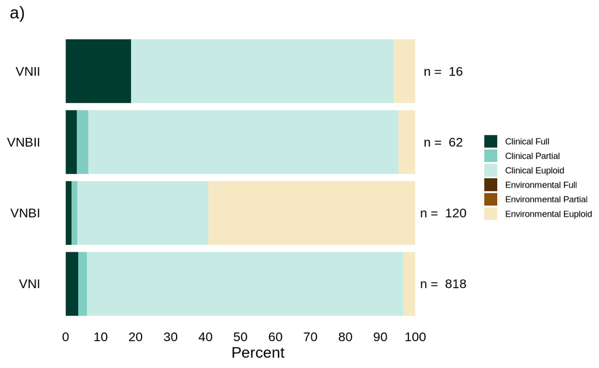

```r
p <- ggplot(dup_lin_source) +
        geom_col(aes(x = lineage, y = percent, fill = source_aneuploidy),
                    color = NA, position = "stack", show.legend = TRUE)+
        scale_fill_manual(
            values = source_aneuploidy_colors,
            limits = names(source_aneuploidy_colors),
            drop = FALSE
        )+
        guides(fill = guide_legend(ncol = 1))+
        geom_text(data = n_lineage,
                    aes(x = lineage, y = 108, label = paste("n = ", samples_in_lineage)),
                    size = 3.5)+
        scale_y_continuous(limits = c(0,110),
                            breaks = seq(0,100, by = 10))+
        coord_flip()+
        theme_minimal()+
        labs(x = "Lineage",
                y = "Percent",
                fill = "Type",
                color = "Source",
                title = "a)")+
        theme(legend.position = "right",
                legend.direction = "vertical",
                legend.title = element_blank(),
                legend.text=element_text(size=7),
                legend.key.size = unit(0.4, unit = "cm"),
                legend.margin=margin(t= 0.1, b = 0.1, unit = "cm"),
                panel.grid.major = element_blank(),
                panel.grid.minor = element_blank(),
                axis.text = element_text(size = 10, color = "black"),
                axis.title.y = element_blank(),
                axis.title.x = element_text(size = 12, color = "black"),
                plot.background = element_rect(fill = "white", color = "white"),
                plot.title = element_text(hjust = -0.09, vjust=1))

p
```

```r
ggsave(barplot_aneup_category_dups_path1, p, height = 3, width = 6.5, units = "in", dpi = 900)
```

**Number of samples with duplications per group of dataset-lineage**

```r
get_summary(df = sample_metrics,
            variable1= "category_aneuploidy",
            variable2= "dataset",
            variable3= "lineage",
            cnv_type= "duplication",
            total_n = "samples_in_dataset_lineage")
```

| category_aneuploidy | dataset | lineage | samples_in_dataset_lineage | n | percent |
| --- | --- | --- | --- | --- | --- |
| Full | Ashton | VNI | 637 | 18 | 2.825746 |
| Full | Desjardins | VNI | 181 | 11 | 6.077348 |
| Full | Desjardins | VNBI | 120 | 2 | 1.666667 |
| Full | Desjardins | VNBII | 62 | 2 | 3.225807 |
| Full | Desjardins | VNII | 16 | 3 | 18.750000 |
| Partial | Ashton | VNI | 637 | 18 | 2.825746 |
| Partial | Desjardins | VNI | 181 | 3 | 1.657459 |
| Partial | Desjardins | VNBI | 120 | 2 | 1.666667 |
| Partial | Desjardins | VNBII | 62 | 2 | 3.225807 |
| Euploid | Ashton | VNI | 637 | 601 | 94.348509 |
| Euploid | Desjardins | VNI | 181 | 167 | 92.265193 |
| Euploid | Desjardins | VNBI | 120 | 116 | 96.666667 |
| Euploid | Desjardins | VNBII | 62 | 58 | 93.548387 |
| Euploid | Desjardins | VNII | 16 | 13 | 81.250000 |

**Number of samples with duplications per VNI sublineage**

```r
get_summary(df =  filter(sample_metrics, lineage == "VNI"),
            variable1= "category_aneuploidy",
            variable2= "sublineage",
            cnv_type= "duplication",
            total_n = "samples_in_sublineage")
```

| category_aneuploidy | sublineage | samples_in_sublineage | n | percent |
| --- | --- | --- | --- | --- |
| Full | VNIa | 683 | 24 | 3.513909 |
| Full | VNIb | 46 | 1 | 2.173913 |
| Full | VNIc | 89 | 4 | 4.494382 |
| Partial | VNIa | 683 | 18 | 2.635432 |
| Partial | VNIb | 46 | 1 | 2.173913 |
| Partial | VNIc | 89 | 2 | 2.247191 |
| Euploid | VNIa | 683 | 641 | 93.850659 |
| Euploid | VNIb | 46 | 44 | 95.652174 |
| Euploid | VNIc | 89 | 83 | 93.258427 |

**Number of samples with duplications in each chromosome**

```r
get_summary(df = filter(chrom_metrics, chrom_category_aneuploidy %in% c("Full", "Partial")),
            variable1= "chrom_category_aneuploidy",
            variable2= "chromosome",
            cnv_type= "duplication",
            total_n = "total_samples")
```

| chrom_category_aneuploidy | chromosome | total_samples | n | percent |
| --- | --- | --- | --- | --- |
| Full | chr01 | 1016 | 2 | 0.1968504 |
| Full | chr04 | 1016 | 1 | 0.0984252 |
| Full | chr06 | 1016 | 2 | 0.1968504 |
| Full | chr09 | 1016 | 6 | 0.5905512 |
| Full | chr12 | 1016 | 12 | 1.1811024 |
| Full | chr13 | 1016 | 12 | 1.1811024 |
| Full | chr14 | 1016 | 3 | 0.2952756 |
| Partial | chr02 | 1016 | 6 | 0.5905512 |
| Partial | chr03 | 1016 | 2 | 0.1968504 |
| Partial | chr04 | 1016 | 1 | 0.0984252 |
| Partial | chr06 | 1016 | 4 | 0.3937008 |
| Partial | chr09 | 1016 | 5 | 0.4921260 |
| Partial | chr10 | 1016 | 1 | 0.0984252 |
| Partial | chr11 | 1016 | 1 | 0.0984252 |
| Partial | chr12 | 1016 | 5 | 0.4921260 |
| Partial | chr13 | 1016 | 2 | 0.1968504 |
| Partial | chr14 | 1016 | 4 | 0.3937008 |

**Number of samples with duplications in each group of chromosome-lineage**

```r
get_summary(df = filter(chrom_metrics, chrom_category_aneuploidy %in% c("Full", "Partial")),
            variable1= "chrom_category_aneuploidy",
            variable2= "chromosome",
            variable3= "lineage",
            cnv_type= "duplication",
            total_n = "samples_in_lineage")
```

| chrom_category_aneuploidy | chromosome | lineage | samples_in_lineage | n | percent |
| --- | --- | --- | --- | --- | --- |
| Full | chr01 | VNI | 818 | 2 | 0.2444988 |
| Full | chr04 | VNI | 818 | 1 | 0.1222494 |
| Full | chr06 | VNI | 818 | 2 | 0.2444988 |
| Full | chr09 | VNI | 818 | 5 | 0.6112469 |
| Full | chr09 | VNBII | 62 | 1 | 1.6129032 |
| Full | chr12 | VNI | 818 | 11 | 1.3447433 |
| Full | chr12 | VNBII | 62 | 1 | 1.6129032 |
| Full | chr13 | VNI | 818 | 8 | 0.9779951 |
| Full | chr13 | VNBI | 120 | 1 | 0.8333333 |
| Full | chr13 | VNII | 16 | 3 | 18.7500000 |
| Full | chr14 | VNI | 818 | 1 | 0.1222494 |
| Full | chr14 | VNBI | 120 | 1 | 0.8333333 |
| Full | chr14 | VNII | 16 | 1 | 6.2500000 |
| Partial | chr02 | VNI | 818 | 6 | 0.7334963 |
| Partial | chr03 | VNI | 818 | 2 | 0.2444988 |
| Partial | chr04 | VNI | 818 | 1 | 0.1222494 |
| Partial | chr06 | VNI | 818 | 3 | 0.3667482 |
| Partial | chr06 | VNBII | 62 | 1 | 1.6129032 |
| Partial | chr09 | VNI | 818 | 4 | 0.4889976 |
| Partial | chr09 | VNBI | 120 | 1 | 0.8333333 |
| Partial | chr10 | VNI | 818 | 1 | 0.1222494 |
| Partial | chr11 | VNI | 818 | 1 | 0.1222494 |
| Partial | chr12 | VNI | 818 | 3 | 0.3667482 |
| Partial | chr12 | VNBI | 120 | 1 | 0.8333333 |
| Partial | chr12 | VNBII | 62 | 1 | 1.6129032 |
| Partial | chr13 | VNI | 818 | 2 | 0.2444988 |
| Partial | chr14 | VNI | 818 | 2 | 0.2444988 |
| Partial | chr14 | VNBI | 120 | 1 | 0.8333333 |
| Partial | chr14 | VNBII | 62 | 1 | 1.6129032 |

**Number and identity of fully duplicated chromosomes per samples**

```r
chrom_metrics %>%
    filter(cnv == "duplication", chrom_category_aneuploidy == "Full")%>%
    group_by(sample, strain, source, lineage, dataset) %>%
    summarise(n_chroms = n_distinct(chromosome),
            chromosomes = paste(chromosome, collapse = ", ")) %>%
    arrange(desc(n_chroms), chromosomes)%>%
    select(sample, strain, lineage, dataset, source, n_chroms, chromosomes)
```

| sample | strain | lineage | dataset | source | n_chroms | chromosomes |
| --- | --- | --- | --- | --- | --- | --- |
| SRS405109 | Bt92 | VNI | Desjardins | Clinical | 2 | chr04, chr13 |
| SRS417641 | C12 | VNII | Desjardins | Clinical | 2 | chr13, chr14 |
| ERS2540951 | 04CN-64-024 | VNI | Ashton | Clinical | 1 | chr01 |
| ERS2541304 | 04CN-65-056 | VNI | Ashton | Clinical | 1 | chr01 |
| ERS2541247 | BMD2209 | VNI | Ashton | Clinical | 1 | chr06 |
| ERS542334 | BK31 | VNI | Ashton | Clinical | 1 | chr06 |
| ERS1142815 | BK200 | VNI | Ashton | Clinical | 1 | chr09 |
| ERS1142869 | BK274 | VNI | Ashton | Clinical | 1 | chr09 |
| ERS1142878 | BK286 | VNI | Ashton | Clinical | 1 | chr09 |
| SRS404772 | Bt141 | VNI | Desjardins | Clinical | 1 | chr09 |
| SRS405145 | Bt117 | VNI | Desjardins | Clinical | 1 | chr09 |
| SRS417606 | Bt109 | VNBII | Desjardins | Clinical | 1 | chr09 |
| ERS1142697 | BK12 | VNI | Ashton | Clinical | 1 | chr12 |
| ERS1142819 | BK204 | VNI | Ashton | Clinical | 1 | chr12 |
| ERS2540986 | 04CN-65-001 | VNI | Ashton | Clinical | 1 | chr12 |
| ERS2541264 | BMD3117 | VNI | Ashton | Clinical | 1 | chr12 |
| ERS2541317 | 04CN-64-090 | VNI | Ashton | Clinical | 1 | chr12 |
| SRS404518 | Bt134 | VNI | Desjardins | Clinical | 1 | chr12 |
| SRS404793 | MW-RSA6134 | VNI | Desjardins | Clinical | 1 | chr12 |
| SRS409064 | MW-RSA1955 | VNI | Desjardins | Clinical | 1 | chr12 |
| SRS417642 | In2632 | VNI | Desjardins | Clinical | 1 | chr12 |
| SRS417652 | MW-RSA2967 | VNBII | Desjardins | Clinical | 1 | chr12 |
| SRS520178 | MW-RSA3834 | VNI | Desjardins | Clinical | 1 | chr12 |
| SRS885916 | PMHc1031A.ENR.INI.LP | VNI | Desjardins | Clinical | 1 | chr12 |
| ERS2540945 | 04CN-65-072 | VNI | Ashton | Clinical | 1 | chr13 |
| ERS2540980 | 04CN-64-011 | VNI | Ashton | Clinical | 1 | chr13 |
| ERS2541126 | BMD3144 | VNI | Ashton | Clinical | 1 | chr13 |
| ERS2541212 | 04CN-03-039 | VNI | Ashton | Clinical | 1 | chr13 |
| ERS2541274 | BMD761 | VNI | Ashton | Clinical | 1 | chr13 |
| ERS542496 | BK217 | VNI | Ashton | Clinical | 1 | chr13 |
| SRS404481 | Bt139 | VNI | Desjardins | Clinical | 1 | chr13 |
| SRS417571 | 8-1 | VNII | Desjardins | Clinical | 1 | chr13 |
| SRS520182 | WM626 | VNII | Desjardins | Clinical | 1 | chr13 |
| SRS885893 | NRHc5045.ENR.CLIN.ISO | VNBI | Desjardins | Clinical | 1 | chr13 |
| SRS404475 | LP-RSA3042 | VNI | Desjardins | Clinical | 1 | chr14 |
| SRS885841 | NRHc5009.REL.INI | VNBI | Desjardins | Clinical | 1 | chr14 |

**Number and identity of partially duplicated chromosomes per samples**

```r
chrom_metrics %>%
    filter(cnv == "duplication", chrom_category_aneuploidy == "Partial")%>%
    group_by(sample, strain, source, lineage, dataset) %>%
    summarise(n_chroms = n_distinct(chromosome),
            chromosomes = paste(chromosome, collapse = ", ")) %>%
    arrange(desc(n_chroms), chromosomes)%>%
    select(sample, strain, lineage, dataset, source, n_chroms, chromosomes)
```

| sample | strain | lineage | dataset | source | n_chroms | chromosomes |
| --- | --- | --- | --- | --- | --- | --- |
| ERS2541358 | CNS_936 | VNI | Ashton | Clinical | 2 | chr02, chr09 |
| ERS2541342 | UI_31647-2 | VNI | Ashton | Clinical | 2 | chr02, chr12 |
| ERS2541061 | 04CN-64-088 | VNI | Ashton | Clinical | 2 | chr03, chr11 |
| ERS2541051 | 04CN-65-032 | VNI | Ashton | Clinical | 2 | chr09, chr12 |
| SRS404743 | Bt34 | VNBII | Desjardins | Clinical | 2 | chr12, chr14 |
| SRS885892 | PMHc1001.ENR | VNBI | Desjardins | Clinical | 2 | chr12, chr14 |
| ERS1142844 | BK241 | VNI | Ashton | Clinical | 1 | chr02 |
| ERS2541222 | 04CN-30-001 | VNI | Ashton | Clinical | 1 | chr02 |
| ERS2541258 | BMD1291 | VNI | Ashton | Clinical | 1 | chr02 |
| ERS2541308 | 04CN-64-081 | VNI | Ashton | Clinical | 1 | chr02 |
| ERS2541335 | BMD101 | VNI | Ashton | Clinical | 1 | chr03 |
| ERS2541319 | 04CN-32-042 | VNI | Ashton | Clinical | 1 | chr04 |
| ERS2541251 | 04CN-03-081 | VNI | Ashton | Clinical | 1 | chr06 |
| ERS542366 | BK35 | VNI | Ashton | Clinical | 1 | chr06 |
| SRS404468 | Bt32 | VNBII | Desjardins | Clinical | 1 | chr06 |
| SRS405137 | Bt97 | VNI | Desjardins | Clinical | 1 | chr06 |
| ERS1142893 | BMD854 | VNI | Ashton | Clinical | 1 | chr09 |
| ERS2541289 | 04CN-11-001 | VNI | Ashton | Clinical | 1 | chr09 |
| SRS881238 | PMHc1026.ENR | VNBI | Desjardins | Clinical | 1 | chr09 |
| ERS2541208 | BMD1534 | VNI | Ashton | Clinical | 1 | chr10 |
| SRS417594 | AD4-92a | VNI | Desjardins | Clinical | 1 | chr12 |
| ERS1142778 | BK142 | VNI | Ashton | Clinical | 1 | chr13 |
| ERS542398 | BK105 | VNI | Ashton | Clinical | 1 | chr13 |
| ERS1142798 | BK179 | VNI | Ashton | Clinical | 1 | chr14 |
| SRS409062 | Bt15 | VNI | Desjardins | Clinical | 1 | chr14 |

## Summaries of duplications by “size” category

**Number of samples with duplications per category**

```r
per_category <- get_summary(df = sample_metrics,
            variable1= "category_size",
            cnv_type= "duplication",
            total_n = "total_samples")

per_category
```

| category_size | total_samples | n | percent |
| --- | --- | --- | --- |
| Large | 1016 | 36 | 3.543307 |
| Medium | 1016 | 25 | 2.460630 |
| Small | 1016 | 88 | 8.661417 |
| Absent | 1016 | 867 | 85.334646 |

```r
per_category %>%
    filter(category_size != "Absent")%>%
    group_by(total_samples)%>%
    reframe(n = sum(n),
            percent = n / total_samples*100 )%>%
    distinct()
```

| total_samples | n | percent |
| --- | --- | --- |
| 1016 | 149 | 14.66535 |

**Number of samples with duplications per lineage**

```r
get_summary(df = sample_metrics,
            variable1= "category_size",
            variable2= "lineage",
            cnv_type= "duplication",
            total_n = "samples_in_lineage")
```

| category_size | lineage | samples_in_lineage | n | percent |
| --- | --- | --- | --- | --- |
| Large | VNI | 818 | 29 | 3.545232 |
| Large | VNBI | 120 | 2 | 1.666667 |
| Large | VNBII | 62 | 2 | 3.225807 |
| Large | VNII | 16 | 3 | 18.750000 |
| Medium | VNI | 818 | 21 | 2.567237 |
| Medium | VNBI | 120 | 2 | 1.666667 |
| Medium | VNBII | 62 | 2 | 3.225807 |
| Small | VNI | 818 | 69 | 8.435208 |
| Small | VNBI | 120 | 17 | 14.166667 |
| Small | VNBII | 62 | 2 | 3.225807 |
| Absent | VNI | 818 | 699 | 85.452323 |
| Absent | VNBI | 120 | 99 | 82.500000 |
| Absent | VNBII | 62 | 56 | 90.322581 |
| Absent | VNII | 16 | 13 | 81.250000 |

**Number of samples with duplications in each group of lineage-source**

```r
dup_lin_source <- get_summary(df = sample_metrics,
            variable1= "source_size",
            variable2= "lineage",
            cnv_type= "duplication",
            total_n = "samples_in_lineage")
dup_lin_source
```

| source_size | lineage | samples_in_lineage | n | percent |
| --- | --- | --- | --- | --- |
| Environmental Absent | VNI | 818 | 28 | 3.422983 |
| Environmental Absent | VNBI | 120 | 64 | 53.333333 |
| Environmental Absent | VNBII | 62 | 3 | 4.838710 |
| Environmental Absent | VNII | 16 | 1 | 6.250000 |
| Environmental Small | VNBI | 120 | 7 | 5.833333 |
| Clinical Absent | VNI | 818 | 671 | 82.029340 |
| Clinical Absent | VNBI | 120 | 35 | 29.166667 |
| Clinical Absent | VNBII | 62 | 53 | 85.483871 |
| Clinical Absent | VNII | 16 | 12 | 75.000000 |
| Clinical Small | VNI | 818 | 69 | 8.435208 |
| Clinical Small | VNBI | 120 | 10 | 8.333333 |
| Clinical Small | VNBII | 62 | 2 | 3.225807 |
| Clinical Medium | VNI | 818 | 21 | 2.567237 |
| Clinical Medium | VNBI | 120 | 2 | 1.666667 |
| Clinical Medium | VNBII | 62 | 2 | 3.225807 |
| Clinical Large | VNI | 818 | 29 | 3.545232 |
| Clinical Large | VNBI | 120 | 2 | 1.666667 |
| Clinical Large | VNBII | 62 | 2 | 3.225807 |
| Clinical Large | VNII | 16 | 3 | 18.750000 |

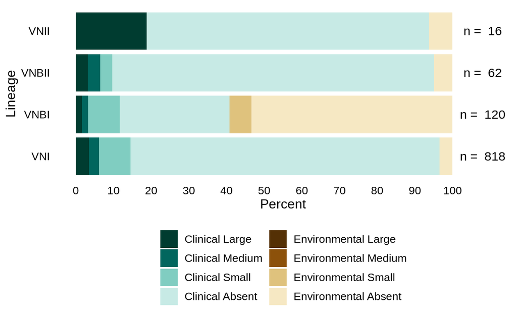

```r
p <- ggplot(dup_lin_source) +
        geom_col(aes(x = lineage, y = percent, fill = source_size),
                    color = NA, position = "stack", show.legend = TRUE)+
        scale_fill_manual(
            values = source_size_colors,
            limits = names(source_size_colors),
            drop = FALSE
        )+
        guides(fill = guide_legend(ncol = 2))+
        geom_text(data = n_lineage,
                    aes(x = lineage, y = 108, label = paste("n = ", samples_in_lineage)),
                    size = 4)+
        scale_y_continuous(limits = c(0,110),
                            breaks = seq(0,100, by = 10))+
        coord_flip()+
        theme_minimal()+
        labs(x = "Lineage",
                y = "Percent",
                fill = "Type",
                color = "Source")+
        theme(legend.position = "bottom",
                legend.direction = "vertical",
                legend.title = element_blank(),
                legend.text=element_text(size=10),
                panel.grid.major = element_blank(),
                panel.grid.minor = element_blank(),
                axis.text = element_text(size = 10, color = "black"),
                axis.title = element_text(size = 12, color = "black"),
                plot.background = element_rect(fill = "white", color = "white")
)
p
```

```r
ggsave(barplot_size_category_dups_path, p, height = 4, width = 6.5, units = "in", dpi = 900)
```

**Number of samples with duplications per group of dataset-lineage**

```r
get_summary(df = sample_metrics,
            variable1= "category_size",
            variable2= "lineage",
            variable3= "dataset",
            cnv_type= "duplication",
            total_n = "samples_in_dataset_lineage")
```

| category_size | lineage | dataset | samples_in_dataset_lineage | n | percent |
| --- | --- | --- | --- | --- | --- |
| Large | VNI | Ashton | 637 | 18 | 2.825746 |
| Large | VNI | Desjardins | 181 | 11 | 6.077348 |
| Large | VNBI | Desjardins | 120 | 2 | 1.666667 |
| Large | VNBII | Desjardins | 62 | 2 | 3.225807 |
| Large | VNII | Desjardins | 16 | 3 | 18.750000 |
| Medium | VNI | Ashton | 637 | 18 | 2.825746 |
| Medium | VNI | Desjardins | 181 | 3 | 1.657459 |
| Medium | VNBI | Desjardins | 120 | 2 | 1.666667 |
| Medium | VNBII | Desjardins | 62 | 2 | 3.225807 |
| Small | VNI | Ashton | 637 | 55 | 8.634223 |
| Small | VNI | Desjardins | 181 | 14 | 7.734807 |
| Small | VNBI | Desjardins | 120 | 17 | 14.166667 |
| Small | VNBII | Desjardins | 62 | 2 | 3.225807 |
| Absent | VNI | Ashton | 637 | 546 | 85.714286 |
| Absent | VNI | Desjardins | 181 | 153 | 84.530387 |
| Absent | VNBI | Desjardins | 120 | 99 | 82.500000 |
| Absent | VNBII | Desjardins | 62 | 56 | 90.322581 |
| Absent | VNII | Desjardins | 16 | 13 | 81.250000 |

**Number of samples with duplications per VNI sublineage**

```r
get_summary(df =  filter(sample_metrics, lineage == "VNI"),
            variable1= "category_size",
            variable2= "sublineage",
            cnv_type= "duplication",
            total_n = "samples_in_sublineage")
```

| category_size | sublineage | samples_in_sublineage | n | percent |
| --- | --- | --- | --- | --- |
| Large | VNIa | 683 | 24 | 3.513909 |
| Large | VNIb | 46 | 1 | 2.173913 |
| Large | VNIc | 89 | 4 | 4.494382 |
| Medium | VNIa | 683 | 18 | 2.635432 |
| Medium | VNIb | 46 | 1 | 2.173913 |
| Medium | VNIc | 89 | 2 | 2.247191 |
| Small | VNIa | 683 | 59 | 8.638360 |
| Small | VNIb | 46 | 6 | 13.043478 |
| Small | VNIc | 89 | 4 | 4.494382 |
| Absent | VNIa | 683 | 582 | 85.212299 |
| Absent | VNIb | 46 | 38 | 82.608696 |
| Absent | VNIc | 89 | 79 | 88.764045 |

**Number of samples with duplications in each chromosome**

```r
get_summary(df = filter(chrom_metrics, chrom_category_size %in% c("Full", "Partial")),
            variable1= "chrom_category_size",
            variable2= "chromosome",
            cnv_type= "duplication",
            total_n = "total_samples")
```

| chrom_category_size | chromosome | total_samples | n | percent |
| --- | --- | --- | --- | --- |

**Number of samples with duplications in each group of chromosome-lineage**

```r
get_summary(df = filter(chrom_metrics, chrom_category_size %in% c("Full", "Partial")),
            variable1= "chrom_category_size",
            variable2= "chromosome",
            variable3= "lineage",
            cnv_type= "duplication",
            total_n = "samples_in_lineage")
```

| chrom_category_size | chromosome | lineage | samples_in_lineage | n | percent |
| --- | --- | --- | --- | --- | --- |

**Number and identity of chromosomes with large duplications per samples**

```r
chrom_metrics %>%
    filter(cnv == "duplication", chrom_category_size == "Large")%>%
    group_by(sample, strain, source, lineage, dataset) %>%
    summarise(n_chroms = n_distinct(chromosome),
            chromosomes = paste(chromosome, collapse = ", ")) %>%
    arrange(desc(n_chroms), chromosomes)%>%
    select(sample, strain, lineage, dataset, source, n_chroms, chromosomes)
```

| sample | strain | lineage | dataset | source | n_chroms | chromosomes |
| --- | --- | --- | --- | --- | --- | --- |
| SRS405109 | Bt92 | VNI | Desjardins | Clinical | 2 | chr04, chr13 |
| SRS417641 | C12 | VNII | Desjardins | Clinical | 2 | chr13, chr14 |
| ERS2540951 | 04CN-64-024 | VNI | Ashton | Clinical | 1 | chr01 |
| ERS2541304 | 04CN-65-056 | VNI | Ashton | Clinical | 1 | chr01 |
| ERS2541247 | BMD2209 | VNI | Ashton | Clinical | 1 | chr06 |
| ERS542334 | BK31 | VNI | Ashton | Clinical | 1 | chr06 |
| ERS1142815 | BK200 | VNI | Ashton | Clinical | 1 | chr09 |
| ERS1142869 | BK274 | VNI | Ashton | Clinical | 1 | chr09 |
| ERS1142878 | BK286 | VNI | Ashton | Clinical | 1 | chr09 |
| SRS404772 | Bt141 | VNI | Desjardins | Clinical | 1 | chr09 |
| SRS405145 | Bt117 | VNI | Desjardins | Clinical | 1 | chr09 |
| SRS417606 | Bt109 | VNBII | Desjardins | Clinical | 1 | chr09 |
| ERS1142697 | BK12 | VNI | Ashton | Clinical | 1 | chr12 |
| ERS1142819 | BK204 | VNI | Ashton | Clinical | 1 | chr12 |
| ERS2540986 | 04CN-65-001 | VNI | Ashton | Clinical | 1 | chr12 |
| ERS2541264 | BMD3117 | VNI | Ashton | Clinical | 1 | chr12 |
| ERS2541317 | 04CN-64-090 | VNI | Ashton | Clinical | 1 | chr12 |
| SRS404518 | Bt134 | VNI | Desjardins | Clinical | 1 | chr12 |
| SRS404793 | MW-RSA6134 | VNI | Desjardins | Clinical | 1 | chr12 |
| SRS409064 | MW-RSA1955 | VNI | Desjardins | Clinical | 1 | chr12 |
| SRS417642 | In2632 | VNI | Desjardins | Clinical | 1 | chr12 |
| SRS417652 | MW-RSA2967 | VNBII | Desjardins | Clinical | 1 | chr12 |
| SRS520178 | MW-RSA3834 | VNI | Desjardins | Clinical | 1 | chr12 |
| SRS885916 | PMHc1031A.ENR.INI.LP | VNI | Desjardins | Clinical | 1 | chr12 |
| ERS2540945 | 04CN-65-072 | VNI | Ashton | Clinical | 1 | chr13 |
| ERS2540980 | 04CN-64-011 | VNI | Ashton | Clinical | 1 | chr13 |
| ERS2541126 | BMD3144 | VNI | Ashton | Clinical | 1 | chr13 |
| ERS2541212 | 04CN-03-039 | VNI | Ashton | Clinical | 1 | chr13 |
| ERS2541274 | BMD761 | VNI | Ashton | Clinical | 1 | chr13 |
| ERS542496 | BK217 | VNI | Ashton | Clinical | 1 | chr13 |
| SRS404481 | Bt139 | VNI | Desjardins | Clinical | 1 | chr13 |
| SRS417571 | 8-1 | VNII | Desjardins | Clinical | 1 | chr13 |
| SRS520182 | WM626 | VNII | Desjardins | Clinical | 1 | chr13 |
| SRS885893 | NRHc5045.ENR.CLIN.ISO | VNBI | Desjardins | Clinical | 1 | chr13 |
| SRS404475 | LP-RSA3042 | VNI | Desjardins | Clinical | 1 | chr14 |
| SRS885841 | NRHc5009.REL.INI | VNBI | Desjardins | Clinical | 1 | chr14 |

**Number and identity of chromosomes with medium duplications per samples**

```r
chrom_metrics %>%
    filter(cnv == "duplication", chrom_category_size == "Medium")%>%
    group_by(sample, strain, source, lineage, dataset) %>%
    summarise(n_chroms = n_distinct(chromosome),
            chromosomes = paste(chromosome, collapse = ", ")) %>%
    arrange(desc(n_chroms), chromosomes)%>%
    select(sample, strain, lineage, dataset, source, n_chroms, chromosomes)
```

| sample | strain | lineage | dataset | source | n_chroms | chromosomes |
| --- | --- | --- | --- | --- | --- | --- |
| ERS2541358 | CNS_936 | VNI | Ashton | Clinical | 2 | chr02, chr09 |
| ERS2541342 | UI_31647-2 | VNI | Ashton | Clinical | 2 | chr02, chr12 |
| ERS2541061 | 04CN-64-088 | VNI | Ashton | Clinical | 2 | chr03, chr11 |
| ERS2541051 | 04CN-65-032 | VNI | Ashton | Clinical | 2 | chr09, chr12 |
| SRS404743 | Bt34 | VNBII | Desjardins | Clinical | 2 | chr12, chr14 |
| SRS885892 | PMHc1001.ENR | VNBI | Desjardins | Clinical | 2 | chr12, chr14 |
| ERS1142844 | BK241 | VNI | Ashton | Clinical | 1 | chr02 |
| ERS2541222 | 04CN-30-001 | VNI | Ashton | Clinical | 1 | chr02 |
| ERS2541258 | BMD1291 | VNI | Ashton | Clinical | 1 | chr02 |
| ERS2541308 | 04CN-64-081 | VNI | Ashton | Clinical | 1 | chr02 |
| ERS2541335 | BMD101 | VNI | Ashton | Clinical | 1 | chr03 |
| ERS2541319 | 04CN-32-042 | VNI | Ashton | Clinical | 1 | chr04 |
| ERS2541251 | 04CN-03-081 | VNI | Ashton | Clinical | 1 | chr06 |
| ERS542366 | BK35 | VNI | Ashton | Clinical | 1 | chr06 |
| SRS404468 | Bt32 | VNBII | Desjardins | Clinical | 1 | chr06 |
| SRS405137 | Bt97 | VNI | Desjardins | Clinical | 1 | chr06 |
| ERS1142893 | BMD854 | VNI | Ashton | Clinical | 1 | chr09 |
| ERS2541289 | 04CN-11-001 | VNI | Ashton | Clinical | 1 | chr09 |
| SRS881238 | PMHc1026.ENR | VNBI | Desjardins | Clinical | 1 | chr09 |
| ERS2541208 | BMD1534 | VNI | Ashton | Clinical | 1 | chr10 |
| SRS417594 | AD4-92a | VNI | Desjardins | Clinical | 1 | chr12 |
| ERS1142778 | BK142 | VNI | Ashton | Clinical | 1 | chr13 |
| ERS542398 | BK105 | VNI | Ashton | Clinical | 1 | chr13 |
| ERS1142798 | BK179 | VNI | Ashton | Clinical | 1 | chr14 |
| SRS409062 | Bt15 | VNI | Desjardins | Clinical | 1 | chr14 |